# Developing an AI application

Going forward, AI algorithms will be incorporated into more and more everyday applications. For example, you might want to include an image classifier in a smart phone app. To do this, you'd use a deep learning model trained on hundreds of thousands of images as part of the overall application architecture. A large part of software development in the future will be using these types of models as common parts of applications.

In this project, you'll train an image classifier to recognize different species of flowers. You can imagine using something like this in a phone app that tells you the name of the flower your camera is looking at. In practice you'd train this classifier, then export it for use in your application. We'll be using [this dataset](http://www.robots.ox.ac.uk/~vgg/data/flowers/102/index.html) of 102 flower categories, you can see a few examples below.

[figure not shown]

The project is broken down into multiple steps:

- Load and preprocess the image dataset
- Train the image classifier on your dataset
- Use the trained classifier to predict image content

We'll lead you through each part which you'll implement in Python.

When you've completed this project, you'll have an application that can be trained on any set of labeled images. Here your network will be learning about flowers and end up as a command line application. But, what you do with your new skills depends on your imagination and effort in building a dataset. For example, imagine an app where you take a picture of a car, it tells you what the make and model is, then looks up information about it. Go build your own dataset and make something new.

First up is importing the packages you'll need. It's good practice to keep all the imports at the beginning of your code. As you work through this notebook and find you need to import a package, make sure to add the import up here.

```python
# Imports here
import numpy as np
import torch
import torch.optim as optim
import torch.optim.lr_scheduler as lr_scheduler
import torch.nn as nn
import torchvision.models as models
import torchvision.transforms as transforms
from torchvision import datasets
from PIL import Image
from PIL import ImageFile
import torch.nn.functional as F
import matplotlib.pyplot as plt
%matplotlib inline
```

## Load the data

Here you'll use `torchvision` to load the data ([documentation](http://pytorch.org/docs/0.3.0/torchvision/index.html)). The data should be included alongside this notebook, otherwise you can [download it here](https://s3.amazonaws.com/content.udacity-data.com/nd089/flower_data.tar.gz). The dataset is split into three parts, training, validation, and testing. For the training, you'll want to apply transformations such as random scaling, cropping, and flipping. This will help the network generalize leading to better performance. You'll also need to make sure the input data is resized to 224x224 pixels as required by the pre-trained networks.

The validation and testing sets are used to measure the model's performance on data it hasn't seen yet. For this you don't want any scaling or rotation transformations, but you'll need to resize then crop the images to the appropriate size.

The pre-trained networks you'll use were trained on the ImageNet dataset where each color channel was normalized separately. For all three sets you'll need to normalize the means and standard deviations of the images to what the network expects. For the means, it's `[0.485, 0.456, 0.406]` and for the standard deviations `[0.229, 0.224, 0.225]`, calculated from the ImageNet images. These values will shift each color channel to be centered at 0 and range from -1 to 1.

```python
data_dir = 'flowers'
train_dir = data_dir + '/train'
valid_dir = data_dir + '/valid'
test_dir = data_dir + '/test'
```

```python
# TODO: Define your transforms for the training, validation, and testing sets

normalize = transforms.Normalize(
   mean=[0.485, 0.456, 0.406],
   std=[0.229, 0.224, 0.225]
)
data_transforms = {
    'test':    transforms.Compose([
               transforms.Resize(256),
               transforms.CenterCrop(224),
               transforms.ToTensor(),
               normalize
                ]),

    'train':   transforms.Compose([
               transforms.RandomRotation(40),  # copy12: change 10 to 40
               transforms.Resize(256),
               transforms.CenterCrop(224),
               transforms.RandomHorizontalFlip(),
               transforms.ToTensor(),
               normalize
                ]),

    'valid':   transforms.Compose([
               transforms.Resize(256),
               transforms.CenterCrop(224),
               transforms.ToTensor(),
               normalize
                ])
        }
# TODO: Load the datasets with ImageFolder
data_dir='flowers/'

image_datasets = {x:datasets.ImageFolder(data_dir+x, transform=data_transforms[x])
             for x in ['train','test','valid']}
# TODO: Using the image datasets and the trainforms, define the dataloaders

batch_size=64
num_workers=0
dataloaders ={
    x:torch.utils.data.DataLoader(image_datasets[x], batch_size=batch_size,
    shuffle=True,num_workers=num_workers)
    for x in ['train','test','valid']
    }
```

### Label mapping

You'll also need to load in a mapping from category label to category name. You can find this in the file `cat_to_name.json`. It's a JSON object which you can read in with the [`json` module](https://docs.python.org/2/library/json.html). This will give you a dictionary mapping the integer encoded categories to the actual names of the flowers.

```python
import json

with open('cat_to_name.json', 'r') as f:
    flower_to_name = json.load(f)
```

```python
flower_to_name
```

```
{'21': 'fire lily',
 '3': 'canterbury bells',
 '45': 'bolero deep blue',
 '1': 'pink primrose',
 '34': 'mexican aster',
 '27': 'prince of wales feathers',
 '7': 'moon orchid',
 '16': 'globe-flower',
 '25': 'grape hyacinth',
 '26': 'corn poppy',
 '79': 'toad lily',
 '39': 'siam tulip',
 '24': 'red ginger',
 '67': 'spring crocus',
 '35': 'alpine sea holly',
 '32': 'garden phlox',
 '10': 'globe thistle',
 '6': 'tiger lily',
 '93': 'ball moss',
 '33': 'love in the mist',
 '9': 'monkshood',
 '102': 'blackberry lily',
 '14': 'spear thistle',
 '19': 'balloon flower',
 '100': 'blanket flower',
 '13': 'king protea',
 '49': 'oxeye daisy',
 '15': 'yellow iris',
 '61': 'cautleya spicata',
 '31': 'carnation',
 '64': 'silverbush',
 '68': 'bearded iris',
 '63': 'black-eyed susan',
 '69': 'windflower',
 '62': 'japanese anemone',
 '20': 'giant white arum lily',
 '38': 'great masterwort',
 '4': 'sweet pea',
 '86': 'tree mallow',
 '101': 'trumpet creeper',
```

[output cut: 47 more lines]

```
 '75': 'thorn apple',
 '41': 'barbeton daisy',
 '95': 'bougainvillea',
 '43': 'sword lily',
 '83': 'hibiscus',
 '78': 'lotus lotus',
 '88': 'cyclamen',
 '94': 'foxglove',
 '81': 'frangipani',
 '74': 'rose',
 '89': 'watercress',
 '73': 'water lily',
 '46': 'wallflower',
 '77': 'passion flower',
 '51': 'petunia'}
```

```python
flower_species=len(flower_to_name)
print(flower_species)
```

```
102
```

```python
flower_to_name[str(4)]
```

```
'sweet pea'
```

# Building and training the classifier

Now that the data is ready, it's time to build and train the classifier. As usual, you should use one of the pretrained models from `torchvision.models` to get the image features. Build and train a new feed-forward classifier using those features.

We're going to leave this part up to you. If you want to talk through it with someone, chat with your fellow students! You can also ask questions on the forums or join the instructors in office hours.

Refer to [the rubric](https://review.udacity.com/#!/rubrics/1663/view) for guidance on successfully completing this section. Things you'll need to do:

- Load a [pre-trained network](http://pytorch.org/docs/master/torchvision/models.html) (If you need a starting point, the VGG networks work great and are straightforward to use)
- Define a new, untrained feed-forward network as a classifier, using ReLU activations and dropout
- Train the classifier layers using backpropagation using the pre-trained network to get the features
- Track the loss and accuracy on the validation set to determine the best hyperparameters

We've left a cell open for you below, but use as many as you need. Our advice is to break the problem up into smaller parts you can run separately. Check that each part is doing what you expect, then move on to the next. You'll likely find that as you work through each part, you'll need to go back and modify your previous code. This is totally normal!

When training make sure you're updating only the weights of the feed-forward network. You should be able to get the validation accuracy above 70% if you build everything right. Make sure to try different hyperparameters (learning rate, units in the classifier, epochs, etc) to find the best model. Save those hyperparameters to use as default values in the next part of the project.

```python
# TODO: Build and train your network
# define VGG16 model
model = models.densenet161(pretrained=True)

for param in model.parameters():
    param.requires_grad=False



print(model)
```

```
DenseNet(
  (features): Sequential(
    (conv0): Conv2d(3, 96, kernel_size=(7, 7), stride=(2, 2), padding=(3, 3), bias=False)
    (norm0): BatchNorm2d(96, eps=1e-05, momentum=0.1, affine=True, track_running_stats=True)
    (relu0): ReLU(inplace)
    (pool0): MaxPool2d(kernel_size=3, stride=2, padding=1, dilation=1, ceil_mode=False)
    (denseblock1): _DenseBlock(
      (denselayer1): _DenseLayer(
        (norm1): BatchNorm2d(96, eps=1e-05, momentum=0.1, affine=True, track_running_stats=True)
        (relu1): ReLU(inplace)
        (conv1): Conv2d(96, 192, kernel_size=(1, 1), stride=(1, 1), bias=False)
        (norm2): BatchNorm2d(192, eps=1e-05, momentum=0.1, affine=True, track_running_stats=True)
        (relu2): ReLU(inplace)
        (conv2): Conv2d(192, 48, kernel_size=(3, 3), stride=(1, 1), padding=(1, 1), bias=False)
      )
      (denselayer2): _DenseLayer(
        (norm1): BatchNorm2d(144, eps=1e-05, momentum=0.1, affine=True, track_running_stats=True)
        (relu1): ReLU(inplace)
        (conv1): Conv2d(144, 192, kernel_size=(1, 1), stride=(1, 1), bias=False)
        (norm2): BatchNorm2d(192, eps=1e-05, momentum=0.1, affine=True, track_running_stats=True)
        (relu2): ReLU(inplace)
        (conv2): Conv2d(192, 48, kernel_size=(3, 3), stride=(1, 1), padding=(1, 1), bias=False)
      )
      (denselayer3): _DenseLayer(
        (norm1): BatchNorm2d(192, eps=1e-05, momentum=0.1, affine=True, track_running_stats=True)
        (relu1): ReLU(inplace)
        (conv1): Conv2d(192, 192, kernel_size=(1, 1), stride=(1, 1), bias=False)
        (norm2): BatchNorm2d(192, eps=1e-05, momentum=0.1, affine=True, track_running_stats=True)
        (relu2): ReLU(inplace)
        (conv2): Conv2d(192, 48, kernel_size=(3, 3), stride=(1, 1), padding=(1, 1), bias=False)
      )
      (denselayer4): _DenseLayer(
        (norm1): BatchNorm2d(240, eps=1e-05, momentum=0.1, affine=True, track_running_stats=True)
        (relu1): ReLU(inplace)
        (conv1): Conv2d(240, 192, kernel_size=(1, 1), stride=(1, 1), bias=False)
        (norm2): BatchNorm2d(192, eps=1e-05, momentum=0.1, affine=True, track_running_stats=True)
        (relu2): ReLU(inplace)
        (conv2): Conv2d(192, 48, kernel_size=(3, 3), stride=(1, 1), padding=(1, 1), bias=False)
      )
      (denselayer5): _DenseLayer(
```

[output cut: 605 more lines]

```
        (conv2): Conv2d(192, 48, kernel_size=(3, 3), stride=(1, 1), padding=(1, 1), bias=False)
      )
      (denselayer24): _DenseLayer(
        (norm1): BatchNorm2d(2160, eps=1e-05, momentum=0.1, affine=True, track_running_stats=True)
        (relu1): ReLU(inplace)
        (conv1): Conv2d(2160, 192, kernel_size=(1, 1), stride=(1, 1), bias=False)
        (norm2): BatchNorm2d(192, eps=1e-05, momentum=0.1, affine=True, track_running_stats=True)
        (relu2): ReLU(inplace)
        (conv2): Conv2d(192, 48, kernel_size=(3, 3), stride=(1, 1), padding=(1, 1), bias=False)
      )
    )
    (norm5): BatchNorm2d(2208, eps=1e-05, momentum=0.1, affine=True, track_running_stats=True)
  )
  (classifier): Linear(in_features=2208, out_features=1000, bias=True)
)
```

```python
#from collections import OrderedDict
model.classifier= nn.Sequential(
                    nn.Linear(model.classifier.in_features,512),
                    nn.ReLU(),
                    nn.Dropout(0.5),
                    nn.Linear(512, flower_species)
                    )
#model.classifier=nn.Linear(model.classifier.in_features,flower_species)

# check if CUDA is available
use_cuda = torch.cuda.is_available()

#use_cuda=False

# move model to GPU if CUDA is available
if use_cuda:
    model = model.cuda()

print(model)
```

```
DenseNet(
  (features): Sequential(
    (conv0): Conv2d(3, 96, kernel_size=(7, 7), stride=(2, 2), padding=(3, 3), bias=False)
    (norm0): BatchNorm2d(96, eps=1e-05, momentum=0.1, affine=True, track_running_stats=True)
    (relu0): ReLU(inplace)
    (pool0): MaxPool2d(kernel_size=3, stride=2, padding=1, dilation=1, ceil_mode=False)
    (denseblock1): _DenseBlock(
      (denselayer1): _DenseLayer(
        (norm1): BatchNorm2d(96, eps=1e-05, momentum=0.1, affine=True, track_running_stats=True)
        (relu1): ReLU(inplace)
        (conv1): Conv2d(96, 192, kernel_size=(1, 1), stride=(1, 1), bias=False)
        (norm2): BatchNorm2d(192, eps=1e-05, momentum=0.1, affine=True, track_running_stats=True)
        (relu2): ReLU(inplace)
        (conv2): Conv2d(192, 48, kernel_size=(3, 3), stride=(1, 1), padding=(1, 1), bias=False)
      )
      (denselayer2): _DenseLayer(
        (norm1): BatchNorm2d(144, eps=1e-05, momentum=0.1, affine=True, track_running_stats=True)
        (relu1): ReLU(inplace)
        (conv1): Conv2d(144, 192, kernel_size=(1, 1), stride=(1, 1), bias=False)
        (norm2): BatchNorm2d(192, eps=1e-05, momentum=0.1, affine=True, track_running_stats=True)
        (relu2): ReLU(inplace)
        (conv2): Conv2d(192, 48, kernel_size=(3, 3), stride=(1, 1), padding=(1, 1), bias=False)
      )
      (denselayer3): _DenseLayer(
        (norm1): BatchNorm2d(192, eps=1e-05, momentum=0.1, affine=True, track_running_stats=True)
        (relu1): ReLU(inplace)
        (conv1): Conv2d(192, 192, kernel_size=(1, 1), stride=(1, 1), bias=False)
        (norm2): BatchNorm2d(192, eps=1e-05, momentum=0.1, affine=True, track_running_stats=True)
        (relu2): ReLU(inplace)
        (conv2): Conv2d(192, 48, kernel_size=(3, 3), stride=(1, 1), padding=(1, 1), bias=False)
      )
      (denselayer4): _DenseLayer(
        (norm1): BatchNorm2d(240, eps=1e-05, momentum=0.1, affine=True, track_running_stats=True)
        (relu1): ReLU(inplace)
        (conv1): Conv2d(240, 192, kernel_size=(1, 1), stride=(1, 1), bias=False)
        (norm2): BatchNorm2d(192, eps=1e-05, momentum=0.1, affine=True, track_running_stats=True)
        (relu2): ReLU(inplace)
        (conv2): Conv2d(192, 48, kernel_size=(3, 3), stride=(1, 1), padding=(1, 1), bias=False)
      )
      (denselayer5): _DenseLayer(
```

[output cut: 610 more lines]

```
        (conv1): Conv2d(2160, 192, kernel_size=(1, 1), stride=(1, 1), bias=False)
        (norm2): BatchNorm2d(192, eps=1e-05, momentum=0.1, affine=True, track_running_stats=True)
        (relu2): ReLU(inplace)
        (conv2): Conv2d(192, 48, kernel_size=(3, 3), stride=(1, 1), padding=(1, 1), bias=False)
      )
    )
    (norm5): BatchNorm2d(2208, eps=1e-05, momentum=0.1, affine=True, track_running_stats=True)
  )
  (classifier): Sequential(
    (0): Linear(in_features=2208, out_features=512, bias=True)
    (1): ReLU()
    (2): Dropout(p=0.5)
    (3): Linear(in_features=512, out_features=102, bias=True)
  )
)
```

```python
ImageFile.LOAD_TRUNCATED_IMAGES = True
def train(n_epochs, loaders, model, optimizer, criterion, use_cuda, save_path):
    """returns trained model"""
    # initialize tracker for minimum validation loss
    valid_loss_min = np.Inf

    for epoch in range(1, n_epochs+1):
        # initialize variables to monitor training and validation loss
        train_loss = 0.0
        valid_loss = 0.0
        valid_accuracy=0.0

        ###################
        # train the model #
        ###################
        model.train()
        for batch_idx, (data, target) in enumerate(loaders['train']):
            # move to GPU
            if use_cuda:
                data, target = data.cuda(), target.cuda()
            ## find the loss and update the model parameters accordingly
            ## record the average training loss, using something like
            ## train_loss = train_loss + ((1 / (batch_idx + 1)) * (loss.data - train_loss))
                    # clear the gradients of all optimized variables
            optimizer.zero_grad()
            # forward pass: compute predicted outputs by passing inputs to the model
            output = model(data)
            # calculate the batch loss
            loss = criterion(output, target)
            # backward pass: compute gradient of the loss with respect to model parameters
            loss.backward()
            # perform a single optimization step (parameter update)
            optimizer.step()
            # update training loss
            train_loss += loss.item()*data.size(0)

        ######################
        # validate the model #
        ######################
        valid_correct=0
        valid_total=0
        model.eval()
        for batch_idx, (data, target) in enumerate(loaders['valid']):
            # move to GPU
            if use_cuda:
                data, target = data.cuda(), target.cuda()
            ## update the average validation loss
            # forward pass: compute predicted outputs by passing inputs to the model
            output = model(data)
            # calculate the batch loss
            loss = criterion(output, target)
            # update average validation loss
            valid_loss += loss.item()*data.size(0)
            pred = output.data.max(1, keepdim=True)[1]
            valid_correct += np.sum(np.squeeze(pred.eq(target.data.view_as(pred))).cpu().numpy())
            valid_total += data.size(0)

        # calculate average losses
        train_loss = train_loss/len(loaders['train'].dataset)
        valid_loss = valid_loss/len(loaders['valid'].dataset)
        valid_accuracy=valid_correct/valid_total
        # print training/validation statistics
        print('Epoch: {} \tTraining Loss: {:.6f} \tValidation Loss: {:.6f} \tValidation Accuracy: {:.6f} {}/{}'.format(
            epoch,
            train_loss,
            valid_loss,
            valid_accuracy, valid_correct, valid_total
            ))

        ## TODO: save the model if validation loss has decreased
        # save model if validation loss has decreased
        if valid_loss <= valid_loss_min:
            print('Validation loss decreased ({:.6f} --> {:.6f}).  Saving model ...'.format(
            valid_loss_min,
            valid_loss))
            torch.save(model.state_dict(), save_path)
            valid_loss_min = valid_loss
    # return trained model
    return model
```

```python
criterion_transfer = nn.CrossEntropyLoss()
optimizer_transfer = optim.Adam(model.classifier.parameters(),lr=0.001)
# Decay LR by a factor of 0.1 every 4 epochs
exp_lr_scheduler = lr_scheduler.StepLR(optimizer_transfer, step_size=4, gamma=0.1)
```

```python
model = train(30, dataloaders, model, optimizer_transfer, criterion_transfer, use_cuda, 'model_transfer_densenet161_new4.pt')
```

```
Epoch: 1 	Training Loss: 3.128926 	Validation Loss: 1.423143 	Validation Accuracy: 0.734719 601/818
Validation loss decreased (inf --> 1.423143).  Saving model ...
Epoch: 2 	Training Loss: 1.193581 	Validation Loss: 0.586728 	Validation Accuracy: 0.891198 729/818
Validation loss decreased (1.423143 --> 0.586728).  Saving model ...
Epoch: 3 	Training Loss: 0.705355 	Validation Loss: 0.398719 	Validation Accuracy: 0.908313 743/818
Validation loss decreased (0.586728 --> 0.398719).  Saving model ...
Epoch: 4 	Training Loss: 0.505752 	Validation Loss: 0.322317 	Validation Accuracy: 0.925428 757/818
Validation loss decreased (0.398719 --> 0.322317).  Saving model ...
Epoch: 5 	Training Loss: 0.393029 	Validation Loss: 0.277660 	Validation Accuracy: 0.937653 767/818
Validation loss decreased (0.322317 --> 0.277660).  Saving model ...
Epoch: 6 	Training Loss: 0.327198 	Validation Loss: 0.248272 	Validation Accuracy: 0.935208 765/818
Validation loss decreased (0.277660 --> 0.248272).  Saving model ...
Epoch: 7 	Training Loss: 0.288063 	Validation Loss: 0.221162 	Validation Accuracy: 0.947433 775/818
Validation loss decreased (0.248272 --> 0.221162).  Saving model ...
Epoch: 8 	Training Loss: 0.253614 	Validation Loss: 0.214853 	Validation Accuracy: 0.948655 776/818
Validation loss decreased (0.221162 --> 0.214853).  Saving model ...
Epoch: 9 	Training Loss: 0.226842 	Validation Loss: 0.203425 	Validation Accuracy: 0.951100 778/818
Validation loss decreased (0.214853 --> 0.203425).  Saving model ...
Epoch: 10 	Training Loss: 0.211295 	Validation Loss: 0.176353 	Validation Accuracy: 0.953545 780/818
Validation loss decreased (0.203425 --> 0.176353).  Saving model ...
Epoch: 11 	Training Loss: 0.185187 	Validation Loss: 0.173457 	Validation Accuracy: 0.963325 788/818
Validation loss decreased (0.176353 --> 0.173457).  Saving model ...
Epoch: 12 	Training Loss: 0.178117 	Validation Loss: 0.178906 	Validation Accuracy: 0.958435 784/818
Epoch: 13 	Training Loss: 0.167149 	Validation Loss: 0.171534 	Validation Accuracy: 0.959658 785/818
Validation loss decreased (0.173457 --> 0.171534).  Saving model ...
Epoch: 14 	Training Loss: 0.147228 	Validation Loss: 0.177720 	Validation Accuracy: 0.959658 785/818
Epoch: 15 	Training Loss: 0.142490 	Validation Loss: 0.154520 	Validation Accuracy: 0.962103 787/818
Validation loss decreased (0.171534 --> 0.154520).  Saving model ...
Epoch: 16 	Training Loss: 0.137225 	Validation Loss: 0.159799 	Validation Accuracy: 0.963325 788/818
Epoch: 17 	Training Loss: 0.128764 	Validation Loss: 0.176401 	Validation Accuracy: 0.947433 775/818
Epoch: 18 	Training Loss: 0.127500 	Validation Loss: 0.158419 	Validation Accuracy: 0.958435 784/818
Epoch: 19 	Training Loss: 0.125696 	Validation Loss: 0.159755 	Validation Accuracy: 0.958435 784/818
Epoch: 20 	Training Loss: 0.112130 	Validation Loss: 0.148637 	Validation Accuracy: 0.960880 786/818
Validation loss decreased (0.154520 --> 0.148637).  Saving model ...
Epoch: 21 	Training Loss: 0.111925 	Validation Loss: 0.157670 	Validation Accuracy: 0.960880 786/818
Epoch: 22 	Training Loss: 0.107270 	Validation Loss: 0.168720 	Validation Accuracy: 0.959658 785/818
Epoch: 23 	Training Loss: 0.109115 	Validation Loss: 0.158801 	Validation Accuracy: 0.959658 785/818
Epoch: 24 	Training Loss: 0.102465 	Validation Loss: 0.187948 	Validation Accuracy: 0.949878 777/818
Epoch: 25 	Training Loss: 0.109703 	Validation Loss: 0.158217 	Validation Accuracy: 0.960880 786/818
Epoch: 26 	Training Loss: 0.096772 	Validation Loss: 0.149335 	Validation Accuracy: 0.960880 786/818
Epoch: 27 	Training Loss: 0.097053 	Validation Loss: 0.154817 	Validation Accuracy: 0.965770 790/818
Epoch: 28 	Training Loss: 0.083917 	Validation Loss: 0.175638 	Validation Accuracy: 0.959658 785/818
Epoch: 29 	Training Loss: 0.089122 	Validation Loss: 0.160365 	Validation Accuracy: 0.957213 783/818
Epoch: 30 	Training Loss: 0.091224 	Validation Loss: 0.144919 	Validation Accuracy: 0.970660 794/818
Validation loss decreased (0.148637 --> 0.144919).  Saving model ...
```

## Testing your network

It's good practice to test your trained network on test data, images the network has never seen either in training or validation. This will give you a good estimate for the model's performance on completely new images. Run the test images through the network and measure the accuracy, the same way you did validation. You should be able to reach around 70% accuracy on the test set if the model has been trained well.

```python
def test(loaders, model, criterion, use_cuda):

    # monitor test loss and accuracy
    test_loss = 0.
    correct = 0.
    total = 0.

    model.eval()
    for batch_idx, (data, target) in enumerate(loaders['test']):
        # move to GPU
        if use_cuda:
            data, target = data.cuda(), target.cuda()
        # forward pass: compute predicted outputs by passing inputs to the model
        output = model(data)
        # calculate the loss
        loss = criterion(output, target)
        # update average test loss
        test_loss = test_loss + ((1 / (batch_idx + 1)) * (loss.data - test_loss))
        # convert output probabilities to predicted class
        pred = output.data.max(1, keepdim=True)[1]
        #print(tuple(zip(pred.data.view_as(target).cpu().numpy(),target.data.cpu().numpy())))
        #print(target)
        # compare predictions to true label
        #print(target.data.cpu().numpy()[pred.data.view_as(target).cpu().numpy()!=target.data.cpu().numpy()])
        #print(pred.data.view_as(target).cpu().numpy()[pred.data.view_as(target).cpu().numpy()!=target.data.cpu().numpy()])
        correct += np.sum(np.squeeze(pred.eq(target.data.view_as(pred))).cpu().numpy())
        total += data.size(0)

    print('Test Loss: {:.6f}\n'.format(test_loss))

    print('\nTest Accuracy: %5.2f%% (%2d/%2d)' % (
        100. * correct / total, correct, total))

model.load_state_dict(torch.load('model_transfer_densenet161_new4.pt'))
# call test function
test(dataloaders, model, criterion_transfer, use_cuda)
```

```
Test Loss: 0.114443


Test Accuracy: 97.31% (797/819)
```

```python
flower_to_name['1']
```

```
'pink primrose'
```

```python
dataiter = iter(dataloaders['test'])
images, labels = dataiter.next()
print(images[0].shape)
```

```
torch.Size([3, 224, 224])
```

## Save the checkpoint

Now that your network is trained, save the model so you can load it later for making predictions. You probably want to save other things such as the mapping of classes to indices which you get from one of the image datasets: `image_datasets['train'].class_to_idx`. You can attach this to the model as an attribute which makes inference easier later on.

`model.class_to_idx = image_datasets['train'].class_to_idx`

Remember that you'll want to completely rebuild the model later so you can use it for inference. Make sure to include any information you need in the checkpoint. If you want to load the model and keep training, you'll want to save the number of epochs as well as the optimizer state, `optimizer.state_dict`. You'll likely want to use this trained model in the next part of the project, so best to save it now.

```python
# TODO: Save the checkpoint
model.class_to_idx = image_datasets['train'].class_to_idx
torch.save({'structure' :'densenet161',
            'hidden_layer':512,
            'state_dict':model.state_dict(),
            'class_to_idx':model.class_to_idx},
            'checkpoint.pth')
```

## Loading the checkpoint

At this point it's good to write a function that can load a checkpoint and rebuild the model. That way you can come back to this project and keep working on it without having to retrain the network.

```python
# TODO: Write a function that loads a checkpoint and rebuilds the model
def load_model(path):
    checkpoint = torch.load('checkpoint.pth')
    structure = checkpoint['structure']
    if structure=='densenet161':
        model = models.densenet161(pretrained=True)
    elif structure=='densenet201':
        model = models.densenet201(pretrained=True)
    else:
        print("Wrong Model")
    for param in model.parameters():
        param.requires_grad=False
    model.classifier= nn.Sequential(
                    nn.Linear(model.classifier.in_features,checkpoint['hidden_layer']),
                    nn.ReLU(),
                    nn.Dropout(0.5),
                    nn.Linear(checkpoint['hidden_layer'], flower_species)
                    )

    model.class_to_idx = checkpoint['class_to_idx']
    model.load_state_dict(checkpoint['state_dict'])
    return model

model=load_model('checkpoint.pth')
print(model)
```

```
DenseNet(
  (features): Sequential(
    (conv0): Conv2d(3, 96, kernel_size=(7, 7), stride=(2, 2), padding=(3, 3), bias=False)
    (norm0): BatchNorm2d(96, eps=1e-05, momentum=0.1, affine=True, track_running_stats=True)
    (relu0): ReLU(inplace)
    (pool0): MaxPool2d(kernel_size=3, stride=2, padding=1, dilation=1, ceil_mode=False)
    (denseblock1): _DenseBlock(
      (denselayer1): _DenseLayer(
        (norm1): BatchNorm2d(96, eps=1e-05, momentum=0.1, affine=True, track_running_stats=True)
        (relu1): ReLU(inplace)
        (conv1): Conv2d(96, 192, kernel_size=(1, 1), stride=(1, 1), bias=False)
        (norm2): BatchNorm2d(192, eps=1e-05, momentum=0.1, affine=True, track_running_stats=True)
        (relu2): ReLU(inplace)
        (conv2): Conv2d(192, 48, kernel_size=(3, 3), stride=(1, 1), padding=(1, 1), bias=False)
      )
      (denselayer2): _DenseLayer(
        (norm1): BatchNorm2d(144, eps=1e-05, momentum=0.1, affine=True, track_running_stats=True)
        (relu1): ReLU(inplace)
        (conv1): Conv2d(144, 192, kernel_size=(1, 1), stride=(1, 1), bias=False)
        (norm2): BatchNorm2d(192, eps=1e-05, momentum=0.1, affine=True, track_running_stats=True)
        (relu2): ReLU(inplace)
        (conv2): Conv2d(192, 48, kernel_size=(3, 3), stride=(1, 1), padding=(1, 1), bias=False)
      )
      (denselayer3): _DenseLayer(
        (norm1): BatchNorm2d(192, eps=1e-05, momentum=0.1, affine=True, track_running_stats=True)
        (relu1): ReLU(inplace)
        (conv1): Conv2d(192, 192, kernel_size=(1, 1), stride=(1, 1), bias=False)
        (norm2): BatchNorm2d(192, eps=1e-05, momentum=0.1, affine=True, track_running_stats=True)
        (relu2): ReLU(inplace)
        (conv2): Conv2d(192, 48, kernel_size=(3, 3), stride=(1, 1), padding=(1, 1), bias=False)
      )
      (denselayer4): _DenseLayer(
        (norm1): BatchNorm2d(240, eps=1e-05, momentum=0.1, affine=True, track_running_stats=True)
        (relu1): ReLU(inplace)
        (conv1): Conv2d(240, 192, kernel_size=(1, 1), stride=(1, 1), bias=False)
        (norm2): BatchNorm2d(192, eps=1e-05, momentum=0.1, affine=True, track_running_stats=True)
        (relu2): ReLU(inplace)
        (conv2): Conv2d(192, 48, kernel_size=(3, 3), stride=(1, 1), padding=(1, 1), bias=False)
      )
      (denselayer5): _DenseLayer(
```

[output cut: 610 more lines]

```
        (conv1): Conv2d(2160, 192, kernel_size=(1, 1), stride=(1, 1), bias=False)
        (norm2): BatchNorm2d(192, eps=1e-05, momentum=0.1, affine=True, track_running_stats=True)
        (relu2): ReLU(inplace)
        (conv2): Conv2d(192, 48, kernel_size=(3, 3), stride=(1, 1), padding=(1, 1), bias=False)
      )
    )
    (norm5): BatchNorm2d(2208, eps=1e-05, momentum=0.1, affine=True, track_running_stats=True)
  )
  (classifier): Sequential(
    (0): Linear(in_features=2208, out_features=512, bias=True)
    (1): ReLU()
    (2): Dropout(p=0.5)
    (3): Linear(in_features=512, out_features=102, bias=True)
  )
)
```

```python
print(model.class_to_idx)
```

```
{'1': 0, '10': 1, '100': 2, '101': 3, '102': 4, '11': 5, '12': 6, '13': 7, '14': 8, '15': 9, '16': 10, '17': 11, '18': 12, '19': 13, '2': 14, '20': 15, '21': 16, '22': 17, '23': 18, '24': 19, '25': 20, '26': 21, '27': 22, '28': 23, '29': 24, '3': 25, '30': 26, '31': 27, '32': 28, '33': 29, '34': 30,…
```

```python
idx_to_class = {model.class_to_idx[i]:i for i in model.class_to_idx.keys()}
print(idx_to_class)
```

```
{0: '1', 1: '10', 2: '100', 3: '101', 4: '102', 5: '11', 6: '12', 7: '13', 8: '14', 9: '15', 10: '16', 11: '17', 12: '18', 13: '19', 14: '2', 15: '20', 16: '21', 17: '22', 18: '23', 19: '24', 20: '25', 21: '26', 22: '27', 23: '28', 24: '29', 25: '3', 26: '30', 27: '31', 28: '32', 29: '33', 30: '34',…
```

# Inference for classification

Now you'll write a function to use a trained network for inference. That is, you'll pass an image into the network and predict the class of the flower in the image. Write a function called `predict` that takes an image and a model, then returns the top $K$ most likely classes along with the probabilities. It should look like

```
probs, classes = predict(image_path, model)
print(probs)
print(classes)
> [ 0.01558163  0.01541934  0.01452626  0.01443549  0.01407339]
> ['70', '3', '45', '62', '55']
```

First you'll need to handle processing the input image such that it can be used in your network.

## Image Preprocessing

You'll want to use `PIL` to load the image ([documentation](https://pillow.readthedocs.io/en/latest/reference/Image.html)). It's best to write a function that preprocesses the image so it can be used as input for the model. This function should process the images in the same manner used for training.

First, resize the images where the shortest side is 256 pixels, keeping the aspect ratio. This can be done with the [`thumbnail`](http://pillow.readthedocs.io/en/3.1.x/reference/Image.html#PIL.Image.Image.thumbnail) or [`resize`](http://pillow.readthedocs.io/en/3.1.x/reference/Image.html#PIL.Image.Image.thumbnail) methods. Then you'll need to crop out the center 224x224 portion of the image.

Color channels of images are typically encoded as integers 0-255, but the model expected floats 0-1. You'll need to convert the values. It's easiest with a Numpy array, which you can get from a PIL image like so `np_image = np.array(pil_image)`.

As before, the network expects the images to be normalized in a specific way. For the means, it's `[0.485, 0.456, 0.406]` and for the standard deviations `[0.229, 0.224, 0.225]`. You'll want to subtract the means from each color channel, then divide by the standard deviation.

And finally, PyTorch expects the color channel to be the first dimension but it's the third dimension in the PIL image and Numpy array. You can reorder dimensions using [`ndarray.transpose`](https://docs.scipy.org/doc/numpy-1.13.0/reference/generated/numpy.ndarray.transpose.html). The color channel needs to be first and retain the order of the other two dimensions.

```python
def process_image(image):
    ''' Scales, crops, and normalizes a PIL image for a PyTorch model,
        returns an Numpy array
    '''
    img_pil = Image.open(image)
    img_np=np.array(img_pil)
    #print(img_np.shape)
    #img_np=img_np.transpose(2,0,1)
    #img_pil=Image.fromarray(img_np)

    adjustments = transforms.Compose([
        transforms.Resize(256),
        transforms.CenterCrop(224),
        transforms.ToTensor(),
        transforms.Normalize(mean=[0.485, 0.456, 0.406], std=[0.229, 0.224, 0.225])
    ])

    img_tensor = adjustments(img_pil)
    #print(img_tensor.shape)

    return img_tensor

    # TODO: Process a PIL image for use in a PyTorch model
```

To check your work, the function below converts a PyTorch tensor and displays it in the notebook. If your `process_image` function works, running the output through this function should return the original image (except for the cropped out portions).

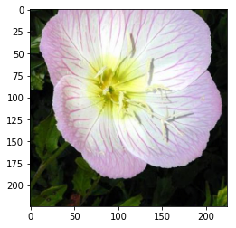

```python
def imshow(image, ax=None, title=None):
    """Imshow for Tensor."""
    if ax is None:
        fig, ax = plt.subplots()

    # PyTorch tensors assume the color channel is the first dimension
    # but matplotlib assumes is the third dimension
    image = image.numpy().transpose((1, 2, 0))

    # Undo preprocessing
    mean = np.array([0.485, 0.456, 0.406])
    std = np.array([0.229, 0.224, 0.225])
    image = std * image + mean

    # Image needs to be clipped between 0 and 1 or it looks like noise when displayed
    image = np.clip(image, 0, 1)

    ax.imshow(image)

    return ax

imshow(process_image("flowers/test/1/image_06743.jpg"))
```

```
torch.Size([3, 224, 224])
tensor([80, 24, 78, 42, 77, 29, 43, 39, 97,  2, 94, 77, 96, 43, 97, 52, 59, 18,
        89, 53, 21, 33, 70, 38, 77, 81, 93, 83, 56, 56, 86, 74, 71, 56, 81, 38,
        24, 51, 40, 43, 89, 97, 10, 55, 59, 70, 73, 53, 38, 74, 36, 27, 50, 51,
         4, 54, 56, 88, 87, 56, 83, 31, 77, 72])
(224, 224, 3)
```

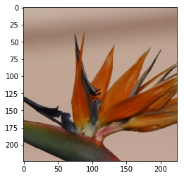

```python
dataiter = iter(dataloaders['test'])
images, labels = dataiter.next()
print(images[0].shape)
print(labels)
test_image = images[0].numpy().transpose((1, 2, 0)) # convert images to numpy for display
mean = np.array([0.485, 0.456, 0.406])
std = np.array([0.229, 0.224, 0.225])
test_image = std * test_image + mean
test_image = np.clip(test_image, 0, 1)
#plt.imshow(np.transpose(train_image, (1, 2, 0)))
print(test_image.shape)
plt.imshow(test_image)
```

```python
print(labels[0].data)
```

```
tensor(80)
```

## Class Prediction

Once you can get images in the correct format, it's time to write a function for making predictions with your model. A common practice is to predict the top 5 or so (usually called top-$K$) most probable classes. You'll want to calculate the class probabilities then find the $K$ largest values.

To get the top $K$ largest values in a tensor use [`x.topk(k)`](http://pytorch.org/docs/master/torch.html#torch.topk). This method returns both the highest `k` probabilities and the indices of those probabilities corresponding to the classes. You need to convert from these indices to the actual class labels using `class_to_idx` which hopefully you added to the model or from an `ImageFolder` you used to load the data (see here). Make sure to invert the dictionary so you get a mapping from index to class as well.

Again, this method should take a path to an image and a model checkpoint, then return the probabilities and classes.

```
probs, classes = predict(image_path, model)
print(probs)
print(classes)
> [ 0.01558163  0.01541934  0.01452626  0.01443549  0.01407339]
> ['70', '3', '45', '62', '55']
```

```python
def predict(image_path, model, topk=5):
    ''' Predict the class (or classes) of an image using a trained deep learning model.
    '''

    # TODO: Implement the code to predict the class from an image file
    model.cuda()
    img_torch = process_image(image_path)
    img_torch = img_torch.unsqueeze_(0).float()
    #img_torch = img_torch.float()
    model.eval()
    with torch.no_grad():
        output = model.forward(img_torch.cuda())

    probability = F.softmax(output.data,dim=1)
    #[np.asscalar(index.cpu().data[0].numpy())]
    value,index=torch.topk(probability,topk)

    return value[0].cpu().data.numpy(),index[0].cpu().data.numpy()
 #   value, index = torch.max(output, 1)



 #   return np.asscalar(index.cpu().data[0].numpy())
```

```python
value,kclass = predict("flowers/test/1/image_06743.jpg", model)
#prob_numpy=prob.cpu().data.numpy()
#print(prob_numpy[0])
print(kclass)
print(value)
```

```
[ 0 84 76 49 87]
[9.9964201e-01 1.6008575e-04 6.6387220e-05 5.8692323e-05 5.8134137e-05]
```

## Sanity Checking

Now that you can use a trained model for predictions, check to make sure it makes sense. Even if the testing accuracy is high, it's always good to check that there aren't obvious bugs. Use `matplotlib` to plot the probabilities for the top 5 classes as a bar graph, along with the input image. It should look like this:

[figure not shown]

You can convert from the class integer encoding to actual flower names with the `cat_to_name.json` file (should have been loaded earlier in the notebook). To show a PyTorch tensor as an image, use the `imshow` function defined above.

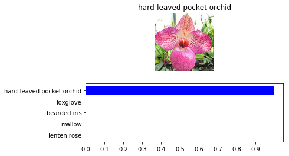

```python
probs, classes = predict('flowers/test/2/image_05109.jpg', model)

classes = [flower_to_name[idx_to_class[c]] for c in classes] #convert class integer to flower name
title = classes[0] #highest probability class
image = imshow(process_image('flowers/test/2/image_05109.jpg'), ax = plt.subplot(2, 1, 1)) #show image
image.axis("off") #removing axis of image
image.set_title(title) #title is highest probability of class

plt.subplot(2, 1, 2)
y_axis = np.arange(5) #top 5 prob
x_axis = np.flip(probs)#np.flip(probs.cpu().data.numpy()[0], 0) #flip numpy array
plt.barh(y_axis, x_axis, align='center', color='blue')
plt.yticks(y_axis, np.flip(classes, 0)) #flip classes
plt.xticks(np.arange(0,1,0.1))
plt.show()
```

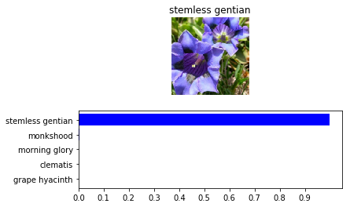

```python
probs, classes = predict('flowers/test/28/image_05230.jpg', model)

classes = [flower_to_name[idx_to_class[c]] for c in classes] #convert class integer to flower name
title = classes[0] #highest probability class
image = imshow(process_image('flowers/test/28/image_05230.jpg'), ax = plt.subplot(2, 1, 1)) #show image
image.axis("off") #removing axis of image
image.set_title(title) #title is highest probability of class

plt.subplot(2, 1, 2)
y_axis = np.arange(5) #top 5 prob
x_axis = np.flip(probs)#np.flip(probs.cpu().data.numpy()[0], 0) #flip numpy array
plt.barh(y_axis, x_axis, align='center', color='blue')
plt.yticks(y_axis, np.flip(classes, 0)) #flip classes
plt.xticks(np.arange(0,1,0.1))
plt.show()
```

```python
flower_to_name['2']
```

```
'hard-leaved pocket orchid'
```

```python
# Import the os module, for the os.walk function
import os

# Set the directory you want to start from
rootDir = 'flowers/test/'
for dirName, subdirList, fileList in os.walk(rootDir):
    print('Found directory: %s' % dirName)
    x=dirName.split('/')
    print(x[-1])
    #for subname in subdirList:
    for fname in fileList:
        print('\t%s/%s' % (dirName, fname))
    #for subname in subdirList:
import os

# Set the directory you want to start from
rootDir = 'flowers/test/'
for dirName, subdirList, fileList in os.walk(rootDir):
    print('Found directory: %s' % dirName)
    x=dirName.split('/')
    print(x[-1])
    #for subname in subdirList:
    for fname in fileList:
        print('\t%s/%s' % (dirName, fname))    #    print('\t%s' % subname)
```

[output not shown]

[output cut: 1995 more lines]

[output not shown]

```python
import os

# Set the directory you want to start from
rootDir = 'flowers/test/'
for dirName, subdirList, fileList in os.walk(rootDir):
    #print('Found directory: %s' % dirName)
    x=dirName.split('/')
    subdir=x[-1]
    #for subname in subdirList:
    for fname in fileList:
        #print('\t%s/%s' % (dirName, fname))
        fileName=dirName+'/'+fname
        values,classes = predict(fileName, model)
        #print(classes)
        #classes = classes.cpu().data.numpy()[1][0]#convert class integer to flower name
        title = classes[0] #highest probability class
        if idx_to_class[title]!=subdir:
            print('miss classified file %s:'%fileName)
            print(idx_to_class[title],subdir)
            print(classes)



#probs, classes = predict('flowers/test/4/image_05637.jpg', model)
```

```
miss classified file flowers/test/11/image_03098.jpg:
7 11
[69 36  5 89 96]
miss classified file flowers/test/26/image_06498.jpg:
58 26
[56 43 90 21 99]
miss classified file flowers/test/32/image_05591.jpg:
51 32
[49 28 72 87 86]
miss classified file flowers/test/37/image_03734.jpg:
87 37
[88 85 33 55 89]
miss classified file flowers/test/4/image_05653.jpg:
9 4
[91 36 83 85 23]
miss classified file flowers/test/4/image_05658.jpg:
88 4
[89 85 81 78 93]
miss classified file flowers/test/4/image_05678.jpg:
37 4
[33 36 16 81 76]
miss classified file flowers/test/40/image_04568.jpg:
69 40
[68 85 98 61 37]
miss classified file flowers/test/40/image_04573.jpg:
83 40
[84 37  0 87 83]
miss classified file flowers/test/45/image_07140.jpg:
75 45
[75 32 42 67 69]
miss classified file flowers/test/48/image_04665.jpg:
42 48
[39 45 64  9 43]
miss classified file flowers/test/51/image_01314.jpg:
75 51
[75 49 76 63 97]
miss classified file flowers/test/51/image_03926.jpg:
94 51
[96 25 89 49 88]
miss classified file flowers/test/52/image_04169.jpg:
```

[output cut: 11 more lines]

```
miss classified file flowers/test/90/image_04417.jpg:
83 90
[84 67 92 40 72]
miss classified file flowers/test/90/image_04469.jpg:
8 90
[80 92 60 12 19]
miss classified file flowers/test/96/image_07676.jpg:
97 96
[99 98 84 74 37]
miss classified file flowers/test/96/image_07683.jpg:
97 96
[99 10 97 98 37]
miss classified file flowers/test/98/image_07758.jpg:
76 98
[76 13  0 84  9]
```

```python
import os
top_1=0
top_2=0
top_3=0
top_4=0
top_5=0
total=0
# Set the directory you want to start from
rootDir = 'flowers/test/'
for dirName, subdirList, fileList in os.walk(rootDir):
    #print('Found directory: %s' % dirName)
    x=dirName.split('/')
    subdir=x[-1]
    #print(type(subdir))
    #for subname in subdirList:
    for fname in fileList:
        #print('\t%s/%s' % (dirName, fname))
        fileName=dirName+'/'+fname
        total+=1
        values,classes = predict(fileName, model)
        #print(classes)
        #classes = classes.cpu().data.numpy()[1][0]#convert class integer to flower name
        title = classes[0] #highest probability class
        if idx_to_class[title]!=subdir:
            print('misclassified file %s:'%fileName)
            print("Prediction: {}, Target: {} ".format(idx_to_class[title],subdir))
            top5_class=[idx_to_class[classes[0]],idx_to_class[classes[1]],idx_to_class[classes[2]],idx_to_class[classes[3]],idx_to_class[classes[4]]]
            print("Top-5 predictions:",top5_class)
            if (subdir not in top5_class):
                top_5+=1
            if (subdir not in top5_class[0:4]):
                top_4+=1
            if (subdir not in top5_class[0:3]):
                top_3+=1
            if (subdir not in top5_class[0:2]):
                top_2+=1
            if (subdir not in top5_class[0:1]):
                top_1+=1
print("Top-5 error rate: {:5.2f}%".format(top_5/total*100))
print("Top-4 error rate: {:5.2f}%".format(top_4/total*100))
print("Top-3 error rate: {:5.2f}%".format(top_3/total*100))
print("Top-2 error rate: {:5.2f}%".format(top_2/total*100))
print("Top-1 error rate: {:5.2f}%".format(top_1/total*100))
```

```
misclassified file flowers/test/11/image_03098.jpg:
Prediction: 7, Target: 11
Top-5 predictions: ['7', '4', '11', '88', '94']
misclassified file flowers/test/26/image_06498.jpg:
Prediction: 58, Target: 26
Top-5 predictions: ['58', '46', '89', '26', '97']
misclassified file flowers/test/32/image_05591.jpg:
Prediction: 51, Target: 32
Top-5 predictions: ['51', '32', '72', '86', '85']
misclassified file flowers/test/37/image_03734.jpg:
Prediction: 87, Target: 37
Top-5 predictions: ['87', '84', '37', '57', '88']
misclassified file flowers/test/4/image_05653.jpg:
Prediction: 9, Target: 4
Top-5 predictions: ['9', '4', '82', '84', '28']
misclassified file flowers/test/4/image_05658.jpg:
Prediction: 88, Target: 4
Top-5 predictions: ['88', '84', '80', '78', '91']
misclassified file flowers/test/4/image_05678.jpg:
Prediction: 37, Target: 4
Top-5 predictions: ['37', '4', '21', '80', '76']
misclassified file flowers/test/40/image_04568.jpg:
Prediction: 69, Target: 40
Top-5 predictions: ['69', '84', '96', '62', '40']
misclassified file flowers/test/40/image_04573.jpg:
Prediction: 83, Target: 40
Top-5 predictions: ['83', '40', '1', '86', '82']
misclassified file flowers/test/45/image_07140.jpg:
Prediction: 75, Target: 45
Top-5 predictions: ['75', '36', '45', '68', '7']
misclassified file flowers/test/48/image_04665.jpg:
Prediction: 42, Target: 48
Top-5 predictions: ['42', '48', '65', '15', '46']
misclassified file flowers/test/51/image_01314.jpg:
Prediction: 75, Target: 51
Top-5 predictions: ['75', '51', '76', '64', '95']
misclassified file flowers/test/51/image_03926.jpg:
Prediction: 94, Target: 51
Top-5 predictions: ['94', '3', '88', '51', '87']
misclassified file flowers/test/52/image_04169.jpg:
```

[output cut: 16 more lines]

```
Top-5 predictions: ['8', '90', '61', '18', '24']
misclassified file flowers/test/96/image_07676.jpg:
Prediction: 97, Target: 96
Top-5 predictions: ['97', '96', '83', '74', '40']
misclassified file flowers/test/96/image_07683.jpg:
Prediction: 97, Target: 96
Top-5 predictions: ['97', '16', '95', '96', '40']
misclassified file flowers/test/98/image_07758.jpg:
Prediction: 76, Target: 98
Top-5 predictions: ['76', '19', '1', '83', '15']
Top-5 error rate:  0.24%
Top-4 error rate:  0.37%
Top-3 error rate:  0.73%
Top-2 error rate:  1.47%
Top-1 error rate:  2.69%
```

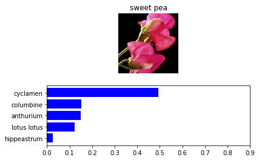

```python
#plt.figure(figsize=(10,10))
probs, classes = predict('flowers/test/4/image_05658.jpg', model)

classes = [flower_to_name[idx_to_class[c]] for c in classes] #convert class integer to flower name
title = flower_to_name[str(4)] #highest probability class
image = imshow(process_image('flowers/test/4/image_05658.jpg'), plt.subplot(2, 1, 1)) #show image
image.axis("off") #removing axis of image
image.set_title(title) #title is highest probability of class

plt.subplot(2, 1, 2)
y_axis = np.arange(5) #top 5 prob
x_axis = np.flip(probs)#np.flip(probs.cpu().data.numpy()[0], 0) #flip numpy array
plt.barh(y_axis, x_axis, align='center', color='blue')
plt.yticks(y_axis, np.flip(classes, 0)) #flip classes
plt.xticks(np.arange(0,1,0.1))
plt.show()
```

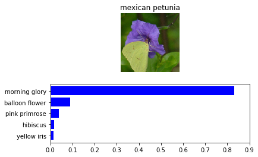

```python
#top-5 error
probs, classes = predict('flowers/test/98/image_07758.jpg', model)

classes = [flower_to_name[idx_to_class[c]] for c in classes] #convert class integer to flower name
title = flower_to_name[str(98)] #highest probability class
image = imshow(process_image('flowers/test/98/image_07758.jpg'), ax = plt.subplot(2, 1, 1)) #show image
image.axis("off") #removing axis of image
image.set_title(title) #title is highest probability of class

plt.subplot(2, 1, 2)
y_axis = np.arange(5) #top 5 prob
x_axis = np.flip(probs)#np.flip(probs.cpu().data.numpy()[0], 0) #flip numpy array
plt.barh(y_axis, x_axis, align='center', color='blue')
plt.yticks(y_axis, np.flip(classes, 0)) #flip classes
plt.xticks(np.arange(0,1,0.1))
plt.show()
```

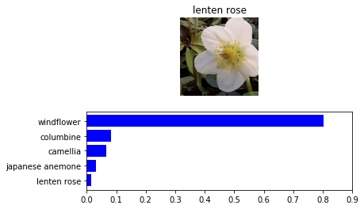

```python
#top-4 error
probs, classes = predict('flowers/test/40/image_04568.jpg', model)

classes = [flower_to_name[idx_to_class[c]] for c in classes] #convert class integer to flower name
title = flower_to_name[str(40)] #highest probability class
image = imshow(process_image('flowers/test/40/image_04568.jpg'), ax = plt.subplot(2, 1, 1)) #show image
image.axis("off") #removing axis of image
image.set_title(title) #title is highest probability of class

plt.subplot(2, 1, 2)
y_axis = np.arange(5) #top 5 prob
x_axis = np.flip(probs)#np.flip(probs.cpu().data.numpy()[0], 0) #flip numpy array
plt.barh(y_axis, x_axis, align='center', color='blue')
plt.yticks(y_axis, np.flip(classes, 0)) #flip classes
plt.xticks(np.arange(0,1,0.1))
plt.show()
```

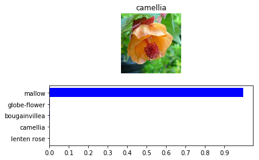

```python
#top-3 error
probs, classes = predict('flowers/test/96/image_07683.jpg', model)

classes = [flower_to_name[idx_to_class[c]] for c in classes] #convert class integer to flower name
title = flower_to_name[str(96)] #highest probability class
image = imshow(process_image('flowers/test/96/image_07683.jpg'), ax = plt.subplot(2, 1, 1)) #show image
image.axis("off") #removing axis of image
image.set_title(title) #title is highest probability of class

plt.subplot(2, 1, 2)
y_axis = np.arange(5) #top 5 prob
x_axis = np.flip(probs)#np.flip(probs.cpu().data.numpy()[0], 0) #flip numpy array
plt.barh(y_axis, x_axis, align='center', color='blue')
plt.yticks(y_axis, np.flip(classes, 0)) #flip classes
plt.xticks(np.arange(0,1,0.1))
plt.show()
```